# Endstopping

Samuel Lippl

30 March 2019

## Natural Statistics

```r
# cifar <- read_cifar_10("1")
# covariance_cifar <-
#     tibble(
#         orientation =
#             c("horizontal", "vertical", "diagonal", "antidiagonal") %>%
#             rep(5),
#         orientation_contrast =
#             c("n", "w", "ne", "nw") %>%
#             rep(5),
#         thickness = rep(1:5, each = 4)
#     ) %>%
#     mutate(
#         covariance =
#             purrr::map2(
#                 orientation_contrast, thickness,
#                 function(it_orientation, it_thickness) {
#                     cifar$bw %>%
#                         map(contrast_filter,
#                             orientation = it_orientation,
#                             thickness = it_thickness) %>%
#                         estimate_contrast_covariance(
#                             contrast_orientation = it_orientation
#                         )
#                 }
#             )
#     )

load("covariance_cifar.RData")
```

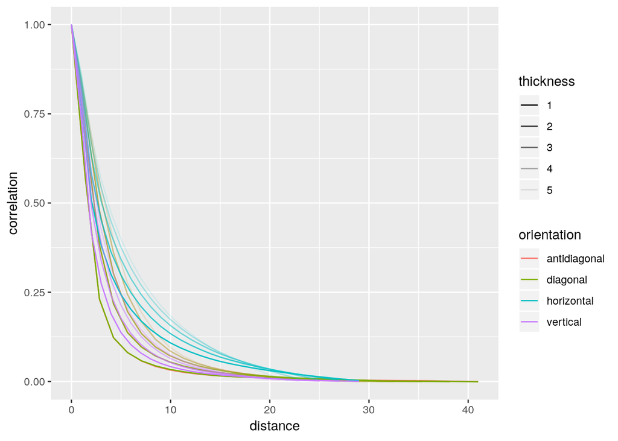

```r
tbl_covariance <-
    covariance_cifar %>%
    mutate(correlation = map(covariance, ~ ./.[1])) %>%
    mutate(distance = map(thickness, ~ (0:(31-2*.)))) %>%
    unnest() %>%
    mutate(distance = if_else(orientation %in% c("horizontal", "vertical"),
                              as_double(distance),
                              sqrt(2)*distance))
tbl_covariance %>%
    ggplot(aes(distance, correlation, colour = orientation, alpha = thickness, group = interaction(thickness, orientation))) +
    geom_line() +
    scale_alpha_continuous(trans = "reverse") +
    # facet_wrap(~thickness) +
    # stat_smooth(method = "nls", formula = y ~ exp(a*x), linetype = 2, method.args = list(start = list(a = -1))) +
    NULL
```

Higher correlation for higher thickness is necessarily the case, but it is good to see that there are no decisive differences. We choose a thickness of 2 from now on.

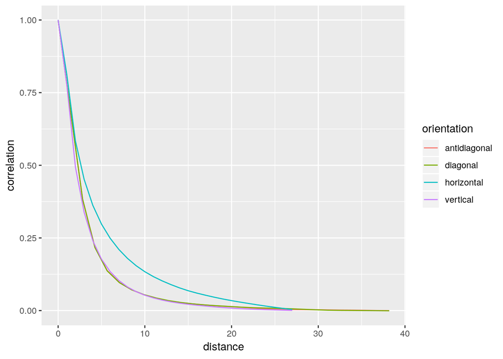

```r
tbl_covariance %>%
    filter(thickness == 2) %>%
    ggplot(aes(distance, correlation, colour = orientation)) +
    geom_line()
```

We first fit a simple exponential model:

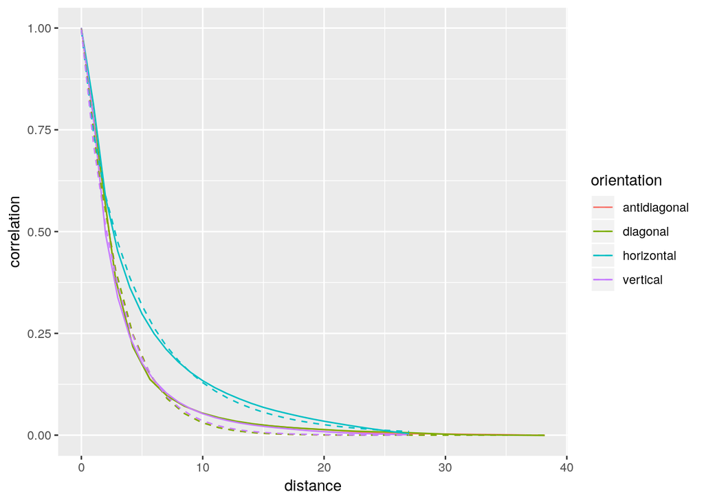

```r
tmp_exp_model <-
    tbl_covariance %>%
    filter(thickness == 2L) %>%
    group_by(orientation) %>%
    nest() %>%
    mutate(
        model = map(data,
                    ~ nls(formula = correlation ~ exp(-a*(distance+.01)^b),
                          data = .,
                          start = list(a = 1, b = 1)) %>%
                        augment() %>%
                        select(.fitted)
        ),
        statistics = map(
            data,
            ~ nls(formula = correlation ~ exp(-a*(distance+.01)^b),
                          data = .,
                          start = list(a = 1, b = 1)) %>%
                        tidy()
        )
    )
exp_model <-
    tmp_exp_model %>%
    unnest(data, model)
exp_model_stats <-
    tmp_exp_model %>%
    unnest(statistics)
exp_model %>%
    ggplot() +
    geom_line(aes(distance, correlation, colour = orientation)) +
    geom_line(aes(distance,
                  .fitted,
                  colour = orientation), linetype = 2)
```

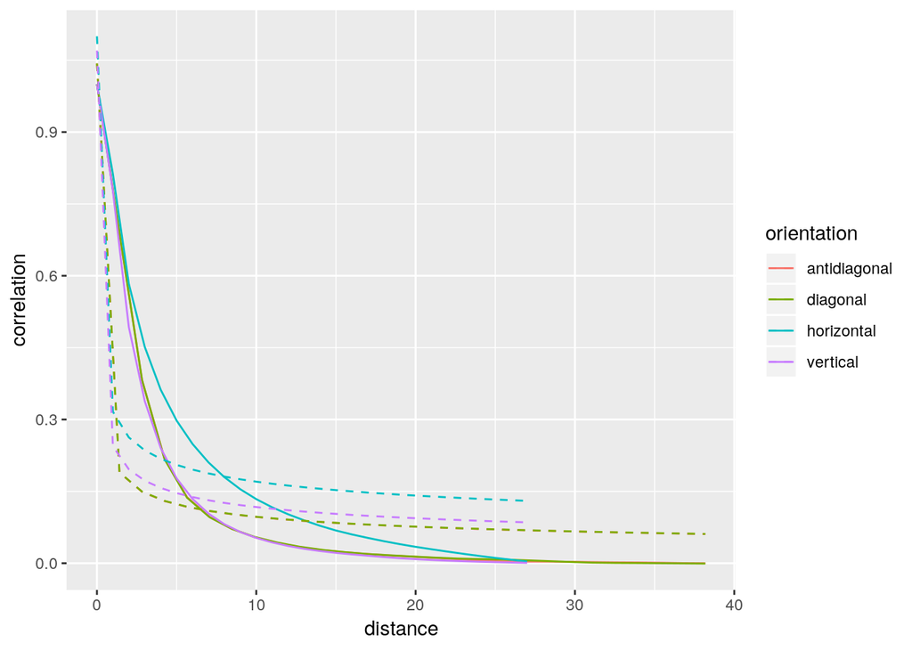

```r
tmp_power_model <-
    tbl_covariance %>%
    filter(thickness == 2L) %>%
    group_by(orientation) %>%
    nest() %>%
    mutate(
        model = map(data,
                    ~ nls(formula = correlation ~ b*(distance+.01)^(-a),
                          data = .,
                          start = list(a = 1, b = 1)) %>%
                        augment() %>%
                        select(.fitted)
        ),
        statistics = map(
            data,
            ~ nls(formula = correlation ~ b*(distance+.01)^(-a),
                          data = .,
                          start = list(a = 1, b = 1)) %>%
                        tidy()
        )
    )
power_model <-
    tmp_power_model %>%
    unnest(data, model)
power_model_stats <-
    tmp_power_model %>%
    unnest(statistics)
power_model %>%
    ggplot() +
    geom_line(aes(distance, correlation, colour = orientation)) +
    geom_line(aes(distance,
                  .fitted,
                  colour = orientation), linetype = 2)
```

This demonstrates that an exponential model fits better than a power law which has more conceptual reasons, as well. (I will elaborate on those in the thesis itself.)

## Endstopping

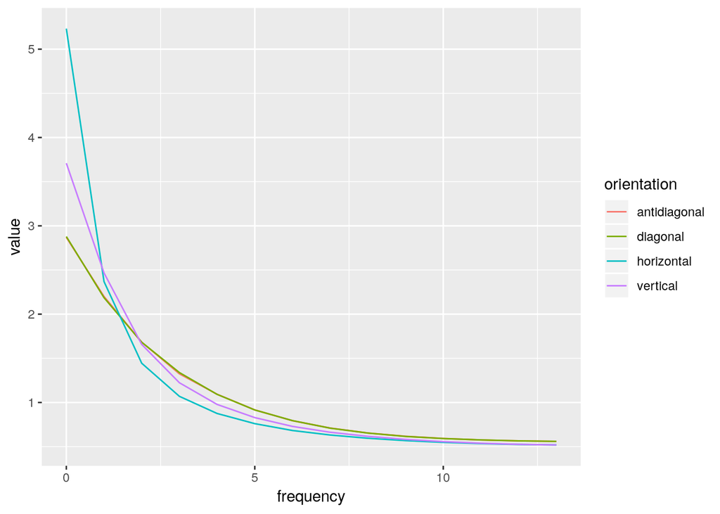

```r
tbl_fourier <-
    tbl_covariance %>%
    filter(thickness == 2L) %>%
    group_by(orientation) %>%
    summarise(
        value = list(
            map_dbl(
                0:floor(n()/2-1),
                ~ sum(correlation * cospi(2*.*(0:(n()-1))/n()))
            )
        ),
        frequency = list(0:floor(n()/2-1))
    ) %>%
    unnest()
tbl_fourier %>%
    ggplot(aes(frequency, value, colour = orientation)) +
    geom_line()
```

This is consistent with the observation of an exponential law, which would imply – regardless of $a$ – that the lower frequency always explain more variance. This means that we can now model an error neuron given an input of length $0\le l\le 30$ for $2k+1$ dimensions, $0\le k\le\frac{n-1}{2}$.

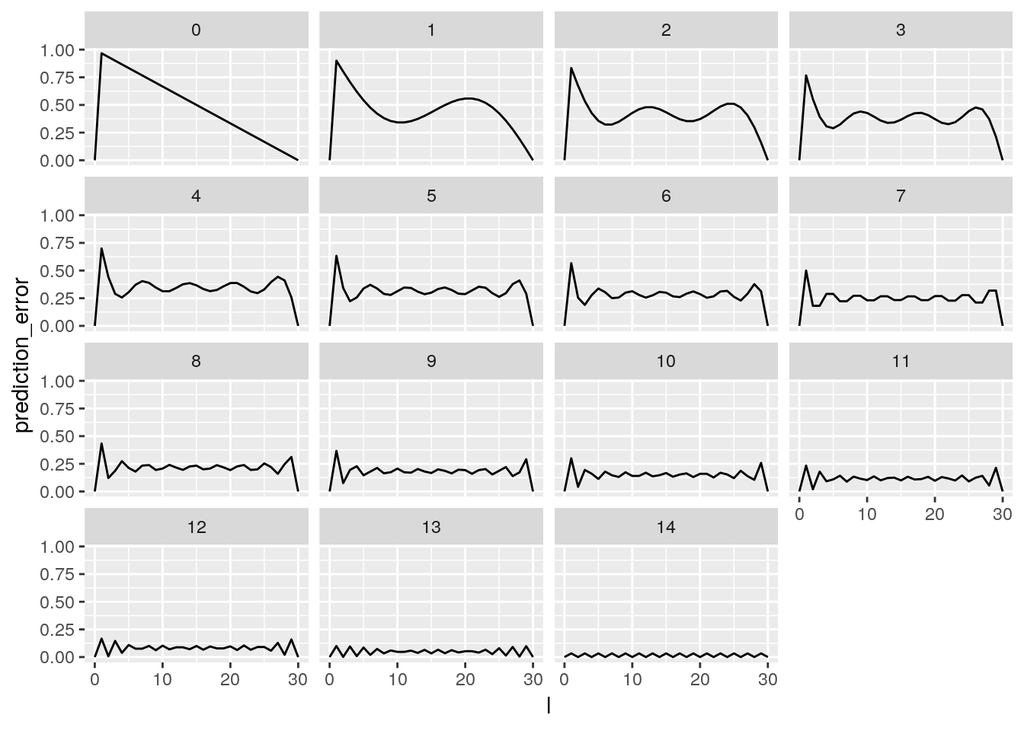

```r
n <- 30
tbl_endstopping <-
    expand.grid(l = 0:n, k=0:((n-1)/2)) %>%
    as_tibble() %>%
    mutate(
        prediction_error =
            map2_dbl(
                l, k,
                function(.l, .k) {
                    (.l>=1) - (
                        .l/n +
                        2/n *
                        sum(
                            purrr::map_dbl(
                                seq_len(.k),
                                ~ sum(cospi(2*./n*(seq_len(.l)-1)))
                            )
                        )
                    )
                }
            )
    )
tbl_endstopping %>%
    ggplot(aes(l, prediction_error)) +
    geom_line() +
    facet_wrap(~k)
```

What happens if we increase maximal n?

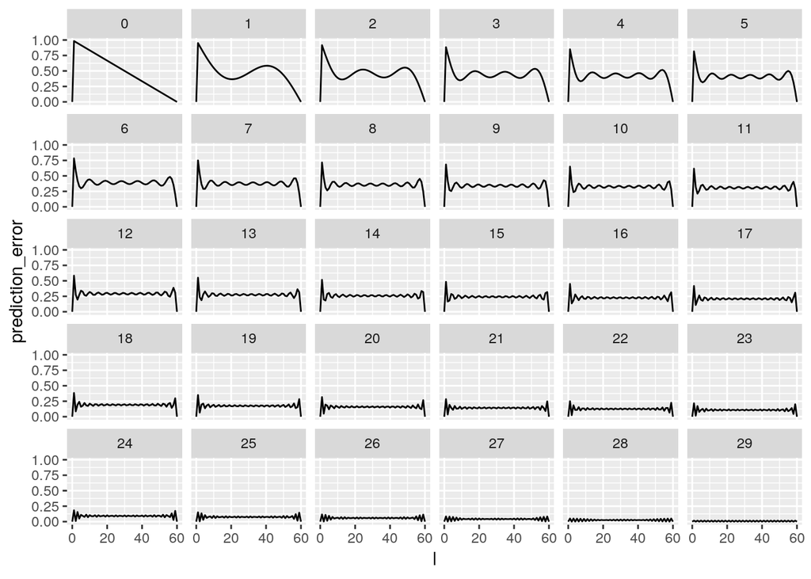

```r
n <- 60
tbl_endstopping_2 <-
    expand.grid(l = 0:n, k=0:((n-1)/2)) %>%
    as_tibble() %>%
    mutate(
        prediction_error =
            map2_dbl(
                l, k,
                function(.l, .k) {
                    (.l>=1) - (
                        .l/n +
                        2/n *
                        sum(
                            purrr::map_dbl(
                                seq_len(.k),
                                ~ sum(cospi(2*./n*(seq_len(.l)-1)))
                            )
                        )
                    )
                }
            )
    )
tbl_endstopping_2 %>%
    ggplot(aes(l, prediction_error)) +
    geom_line() +
    facet_wrap(~k)
```